# Practical Machine Learning - Course Project

Yamila M. Omar

# Summary

In this work, I analyze a Human Activity Recognition dataset provided by:

[Velloso, E.; Bulling, A.; Gellersen, H.; Ugulino, W.; Fuks, H. Qualitative Activity Recognition of Weight Lifting Exercises. Proceedings of 4th International Conference in Cooperation with SIGCHI (Augmented Human ’13) . Stuttgart, Germany: ACM SIGCHI, 2013.](http://groupware.les.inf.puc-rio.br/har)

with the aim to determine *how well* a weight lifting exercise is being performed. To this aim, I use data from sensors located in the belt, arm, forearm and dumbbell used by the test subject. The data will be analyzed, summarized and used to train a *random forest* model which will allow me to classify new data points in one of five available categories.

# Analysis

For simplicity, all necessary libraries will be loaded now. If you wish to reproduce this work, make sure you have installed these libraries using the `install.packages` command.

```r
library(caret)
library(dplyr)
library(ggplot2)
library(reshape2) # used for its melt function for the confusion matrix plot
```

### Loading the data

I will load the data and choose only a handful of columns. The reason for this is that many columns are full of NAs, empty or do not represent variables important to the problem of determining *how well* the activity is being performed (for example `raw_timestamp_part1`, `raw_timestamp_part2`, `new_window`, etc). I made this decision after looking at `head(mydf)`. I do not print this command here to save space.

```r
mydf <- read.csv("./data/pml-training.csv")

mydf <- mydf %>% select(user_name, roll_belt, pitch_belt, yaw_belt,
                        total_accel_belt, gyros_belt_x, gyros_belt_y,
                        gyros_belt_z,
                        accel_belt_x, accel_belt_y, accel_belt_z,
                        magnet_belt_x, magnet_belt_y, magnet_belt_z,
                        roll_arm, pitch_arm, yaw_arm,
                        total_accel_arm, gyros_arm_x, gyros_arm_y, gyros_arm_z,
                        accel_arm_x, accel_arm_y, accel_arm_z,
                        magnet_arm_x, magnet_arm_y, magnet_arm_z,
                        roll_dumbbell, pitch_dumbbell, yaw_dumbbell,
                        total_accel_dumbbell, gyros_dumbbell_x, gyros_dumbbell_y,
                        gyros_dumbbell_z,
                        accel_dumbbell_x, accel_dumbbell_y, accel_dumbbell_z,
                        magnet_dumbbell_x, magnet_dumbbell_y, magnet_dumbbell_z,
                        roll_forearm, pitch_forearm, yaw_forearm,
                        total_accel_forearm, gyros_forearm_x, gyros_forearm_y,
                        gyros_forearm_z,
                        accel_forearm_x, accel_forearm_y, accel_forearm_z,
                        magnet_forearm_x, magnet_forearm_y, magnet_forearm_z,
                        classe)
```

### Data Partition

Next, I will separate the data into **training** and **testing** sets using the `createDataPartition` command from the `caret` package. I will train my model on the former and test its accuracy on the later.

```r
set.seed(123)
aux <- createDataPartition(mydf$classe, p = 0.75, list = FALSE)
dtrain <- mydf[aux, ]
dtest <- mydf[-aux, ]
```

### Pre-processing and modeling

The dimensions of our `dtrain` dataset are 14718 rows and 54 columns. As you can imagine, training a prediction algorithm with 52 numerical variables (`user_name` and the outcome, `classe`, are factor variables) would require a lot of computational time. For that reason, I will use **Principal Component Analysis** (PCA) to summarize the information contained in my `dtrain` data frame.

```r
# We find the pre-processing model using the preProcess function from caret
ppm <- preProcess(dtrain[ , 2:53], method = "pca")
trainPC <- predict(ppm, dtrain[ , 2:53])
```

I will now train a **random forest** using my new data frame `trainPC`. I will use **cross validation** within the `train` command from the `caret` package. From the `?trainControl` command, I learnt that `method` is the resampling method chosen, which in my case is cross-validation (coded as `"cv"`). The number of folds or resampling iterations is set by default as 10.

```r
mdl <- train(dtrain$classe ~ ., data = trainPC, method = "rf",
             trControl = trainControl(method = "cv"))
mdl
```

```
## Random Forest
##
## 14718 samples
##    24 predictor
##     5 classes: 'A', 'B', 'C', 'D', 'E'
##
## No pre-processing
## Resampling: Cross-Validated (10 fold)
## Summary of sample sizes: 13247, 13245, 13247, 13248, 13247, 13245, ...
## Resampling results across tuning parameters:
##
##   mtry  Accuracy   Kappa      Accuracy SD  Kappa SD
##    2    0.9749972  0.9683676  0.004454494  0.005637988
##   13    0.9702422  0.9623589  0.006007687  0.007604784
##   25    0.9668457  0.9580620  0.006119953  0.007739255
##
## Accuracy was used to select the optimal model using  the largest value.
## The final value used for the model was mtry = 2.
```

```r
mdl$finalModel
```

```
##
## Call:
##  randomForest(x = x, y = y, mtry = param$mtry)
##                Type of random forest: classification
##                      Number of trees: 500
## No. of variables tried at each split: 2
##
##         OOB estimate of  error rate: 2.3%
## Confusion matrix:
##      A    B    C    D    E class.error
## A 4146   13   17    6    3 0.009318996
## B   56 2752   35    1    4 0.033707865
## C    4   33 2507   20    3 0.023373588
## D    3    1   97 2306    5 0.043946932
## E    2    7   14   15 2668 0.014042868
```

### Testing the model and accuracy

Now that I have my model, I will use it to predict the `classe` variable in the test data set. I will then use the `confusionMatrix` command from `caret` to determine the **out-of-sample error**.

```r
testPC <- predict(ppm, dtest[ , 2:53])
prediction <- predict(mdl, newdata = testPC)
confusionMatrix(prediction, dtest$classe)
```

```
## Confusion Matrix and Statistics
##
##           Reference
## Prediction    A    B    C    D    E
##          A 1392    8    1    1    0
##          B    2  926   10    0    1
##          C    0   13  837   39   11
##          D    0    0    5  764    5
##          E    1    2    2    0  884
##
## Overall Statistics
##
##                Accuracy : 0.9794
##                  95% CI : (0.975, 0.9832)
##     No Information Rate : 0.2845
##     P-Value [Acc > NIR] : < 2.2e-16
##
##                   Kappa : 0.9739
##  Mcnemar's Test P-Value : NA
##
## Statistics by Class:
##
##                      Class: A Class: B Class: C Class: D Class: E
## Sensitivity            0.9978   0.9758   0.9789   0.9502   0.9811
## Specificity            0.9972   0.9967   0.9844   0.9976   0.9988
## Pos Pred Value         0.9929   0.9862   0.9300   0.9871   0.9944
## Neg Pred Value         0.9991   0.9942   0.9955   0.9903   0.9958
## Prevalence             0.2845   0.1935   0.1743   0.1639   0.1837
## Detection Rate         0.2838   0.1888   0.1707   0.1558   0.1803
## Detection Prevalence   0.2859   0.1915   0.1835   0.1578   0.1813
## Balanced Accuracy      0.9975   0.9862   0.9817   0.9739   0.9899
```

As it can be seen in the confusion matrix above (and in the Figure below), the model has an out-of-sample overall accuracy of 97.94%. In other words, the **out-of-sample error** is 2.06%. It is also remarkable that the sensitivity, i.e. the probability of positively identify the `classe` given that a data point belongs to it, is above 95% for all classes. The specificity, i.e. the probability that the method determines that a point does not belong to a `classe` when it does not, is above 98% in all cases.

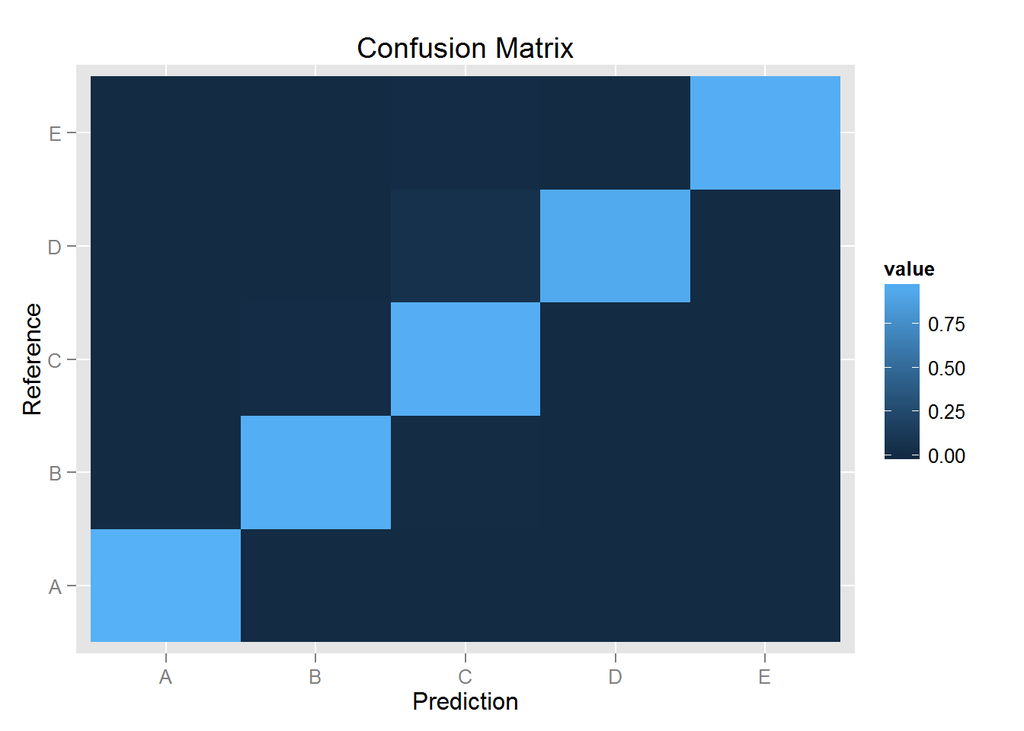

```r
confmatrix <- as.matrix(confusionMatrix(prediction, dtest$classe))
confmatrix <- apply(confmatrix, 2, function(x) round(x/sum(x), 3))
p <- ggplot(melt(confmatrix), aes(x=Var1, y=Var2, fill=value)) +
        geom_tile()
p + xlab("Prediction") + ylab("Reference") + ggtitle("Confusion Matrix")
```

# Apendix

### Exploratory Data Analysis

```r
str(mydf)
```

```
## 'data.frame':    19622 obs. of  54 variables:
##  $ user_name           : Factor w/ 6 levels "adelmo","carlitos",..: 2 2 2 2 2 2 2 2 2 2 ...
##  $ roll_belt           : num  1.41 1.41 1.42 1.48 1.48 1.45 1.42 1.42 1.43 1.45 ...
##  $ pitch_belt          : num  8.07 8.07 8.07 8.05 8.07 8.06 8.09 8.13 8.16 8.17 ...
##  $ yaw_belt            : num  -94.4 -94.4 -94.4 -94.4 -94.4 -94.4 -94.4 -94.4 -94.4 -94.4 ...
##  $ total_accel_belt    : int  3 3 3 3 3 3 3 3 3 3 ...
##  $ gyros_belt_x        : num  0 0.02 0 0.02 0.02 0.02 0.02 0.02 0.02 0.03 ...
##  $ gyros_belt_y        : num  0 0 0 0 0.02 0 0 0 0 0 ...
##  $ gyros_belt_z        : num  -0.02 -0.02 -0.02 -0.03 -0.02 -0.02 -0.02 -0.02 -0.02 0 ...
##  $ accel_belt_x        : int  -21 -22 -20 -22 -21 -21 -22 -22 -20 -21 ...
##  $ accel_belt_y        : int  4 4 5 3 2 4 3 4 2 4 ...
##  $ accel_belt_z        : int  22 22 23 21 24 21 21 21 24 22 ...
##  $ magnet_belt_x       : int  -3 -7 -2 -6 -6 0 -4 -2 1 -3 ...
##  $ magnet_belt_y       : int  599 608 600 604 600 603 599 603 602 609 ...
##  $ magnet_belt_z       : int  -313 -311 -305 -310 -302 -312 -311 -313 -312 -308 ...
```

[output cut: 40 more lines]

```r
summary(mydf)
```

```
##     user_name      roll_belt        pitch_belt          yaw_belt
##  adelmo  :3892   Min.   :-28.90   Min.   :-55.8000   Min.   :-180.00
##  carlitos:3112   1st Qu.:  1.10   1st Qu.:  1.7600   1st Qu.: -88.30
##  charles :3536   Median :113.00   Median :  5.2800   Median : -13.00
##  eurico  :3070   Mean   : 64.41   Mean   :  0.3053   Mean   : -11.21
##  jeremy  :3402   3rd Qu.:123.00   3rd Qu.: 14.9000   3rd Qu.:  12.90
##  pedro   :2610   Max.   :162.00   Max.   : 60.3000   Max.   : 179.00
##  total_accel_belt  gyros_belt_x        gyros_belt_y       gyros_belt_z
##  Min.   : 0.00    Min.   :-1.040000   Min.   :-0.64000   Min.   :-1.4600
##  1st Qu.: 3.00    1st Qu.:-0.030000   1st Qu.: 0.00000   1st Qu.:-0.2000
##  Median :17.00    Median : 0.030000   Median : 0.02000   Median :-0.1000
##  Mean   :11.31    Mean   :-0.005592   Mean   : 0.03959   Mean   :-0.1305
##  3rd Qu.:18.00    3rd Qu.: 0.110000   3rd Qu.: 0.11000   3rd Qu.:-0.0200
##  Max.   :29.00    Max.   : 2.220000   Max.   : 0.64000   Max.   : 1.6200
##   accel_belt_x       accel_belt_y     accel_belt_z     magnet_belt_x
##  Min.   :-120.000   Min.   :-69.00   Min.   :-275.00   Min.   :-52.0
##  1st Qu.: -21.000   1st Qu.:  3.00   1st Qu.:-162.00   1st Qu.:  9.0
##  Median : -15.000   Median : 35.00   Median :-152.00   Median : 35.0
##  Mean   :  -5.595   Mean   : 30.15   Mean   : -72.59   Mean   : 55.6
##  3rd Qu.:  -5.000   3rd Qu.: 61.00   3rd Qu.:  27.00   3rd Qu.: 59.0
##  Max.   :  85.000   Max.   :164.00   Max.   : 105.00   Max.   :485.0
##  magnet_belt_y   magnet_belt_z       roll_arm         pitch_arm
##  Min.   :354.0   Min.   :-623.0   Min.   :-180.00   Min.   :-88.800
##  1st Qu.:581.0   1st Qu.:-375.0   1st Qu.: -31.77   1st Qu.:-25.900
##  Median :601.0   Median :-320.0   Median :   0.00   Median :  0.000
##  Mean   :593.7   Mean   :-345.5   Mean   :  17.83   Mean   : -4.612
##  3rd Qu.:610.0   3rd Qu.:-306.0   3rd Qu.:  77.30   3rd Qu.: 11.200
##  Max.   :673.0   Max.   : 293.0   Max.   : 180.00   Max.   : 88.500
##     yaw_arm          total_accel_arm  gyros_arm_x        gyros_arm_y
##  Min.   :-180.0000   Min.   : 1.00   Min.   :-6.37000   Min.   :-3.4400
##  1st Qu.: -43.1000   1st Qu.:17.00   1st Qu.:-1.33000   1st Qu.:-0.8000
##  Median :   0.0000   Median :27.00   Median : 0.08000   Median :-0.2400
##  Mean   :  -0.6188   Mean   :25.51   Mean   : 0.04277   Mean   :-0.2571
##  3rd Qu.:  45.8750   3rd Qu.:33.00   3rd Qu.: 1.57000   3rd Qu.: 0.1400
##  Max.   : 180.0000   Max.   :66.00   Max.   : 4.87000   Max.   : 2.8400
##   gyros_arm_z       accel_arm_x       accel_arm_y      accel_arm_z
##  Min.   :-2.3300   Min.   :-404.00   Min.   :-318.0   Min.   :-636.00
##  1st Qu.:-0.0700   1st Qu.:-242.00   1st Qu.: -54.0   1st Qu.:-143.00
##  Median : 0.2300   Median : -44.00   Median :  14.0   Median : -47.00
##  Mean   : 0.2695   Mean   : -60.24   Mean   :  32.6   Mean   : -71.25
```

[output cut: 50 more lines]

```
##  Max.   :311.00000   Max.   :231.0000   Max.   : 477.00   Max.   : 923.0
##  accel_forearm_z   magnet_forearm_x  magnet_forearm_y magnet_forearm_z
##  Min.   :-446.00   Min.   :-1280.0   Min.   :-896.0   Min.   :-973.0
##  1st Qu.:-182.00   1st Qu.: -616.0   1st Qu.:   2.0   1st Qu.: 191.0
##  Median : -39.00   Median : -378.0   Median : 591.0   Median : 511.0
##  Mean   : -55.29   Mean   : -312.6   Mean   : 380.1   Mean   : 393.6
##  3rd Qu.:  26.00   3rd Qu.:  -73.0   3rd Qu.: 737.0   3rd Qu.: 653.0
##  Max.   : 291.00   Max.   :  672.0   Max.   :1480.0   Max.   :1090.0
##  classe
##  A:5580
##  B:3797
##  C:3422
##  D:3216
##  E:3607
##
```

### Solution to the second part of the assignment

I share the code for this part of the asignment. However, I will not make the answers visible.

```r
# Read the data
mytest <- read.csv("./data/pml-testing.csv")

# Select the appropriate variables
mytest2 <- mytest %>% select(user_name, roll_belt, pitch_belt, yaw_belt,
                        total_accel_belt, gyros_belt_x, gyros_belt_y,
                        gyros_belt_z,
                        accel_belt_x, accel_belt_y, accel_belt_z,
                        magnet_belt_x, magnet_belt_y, magnet_belt_z,
                        roll_arm, pitch_arm, yaw_arm,
                        total_accel_arm, gyros_arm_x, gyros_arm_y, gyros_arm_z,
                        accel_arm_x, accel_arm_y, accel_arm_z,
                        magnet_arm_x, magnet_arm_y, magnet_arm_z,
                        roll_dumbbell, pitch_dumbbell, yaw_dumbbell,
                        total_accel_dumbbell, gyros_dumbbell_x, gyros_dumbbell_y,
                        gyros_dumbbell_z,
                        accel_dumbbell_x, accel_dumbbell_y, accel_dumbbell_z,
                        magnet_dumbbell_x, magnet_dumbbell_y, magnet_dumbbell_z,
                        roll_forearm, pitch_forearm, yaw_forearm,
                        total_accel_forearm, gyros_forearm_x, gyros_forearm_y,
                        gyros_forearm_z,
                        accel_forearm_x, accel_forearm_y, accel_forearm_z,
                        magnet_forearm_x, magnet_forearm_y, magnet_forearm_z)

# Predict the values of the principal components
mytest2PC <- predict(ppm, newdata = mytest2[ , 2:53])

# Save the solution
answer <- data.frame(problem_id = mytest$problem_id)
answer$prediction <- predict(mdl, newdata = mytest2PC)

# Show the solution
answer
```

And this is the code I used to save the answers in text files. It is a slight variation as that proposed by the instructor of the course.

```r
# We force the prediction to character format
answer$prediction <- as.character(answer$prediction)

# We save the answers
n = length(answer$problem_id)

for(i in 1:n){
    filename = paste0("./answer/problem_id_",i,".txt")
    write.table(answer$prediction[i], file = filename, quote = FALSE,
                row.names = FALSE, col.names = FALSE)
}
```

I have submitted it for evaluation. I received 18 out of 20 points. Predictions for `problem_id_6` and `problem_id_11` were incorrect. From this, the accuracy could be estimated to be 90%.